# Virginia Election Project

- Show All Code
- Hide All Code
- View Source

Author

Joshua K. De La Torre

Introduction: This Code Walkthrough will use the joined_vacomparison dataset to analyze the electoral performance of presidential and gubernatorial candidates during the national elections. This walkthrough will be a step by step guide into the process of using datasets as potential sources for stories. This includes a comparison of total votes between candidates, % difference of votes, as well as steps to visualize them into tables and charts.

# Comparing Virginia Gov vs. Prez

```r
head(joined_vacomparison)
```

```
# A tibble: 6 x 9
  locality       biden trump biden_pct trump_pct youngkin mcauliffe pct_youngkin
  <chr>          <dbl> <dbl>     <dbl>     <dbl>    <int>     <int>        <dbl>
1 ACCOMACK COUN~  7578  9172      44.7      54.1     7878      4948         61.1
2 ALBEMARLE COU~ 42466 20804      65.7      32.2    19141     31919         37.2
3 ALEXANDRIA CI~ 66240 14544      80.3      17.6    14013     43866         24.0
4 ALLEGHANY COU~  2243  5859      27.3      71.4     4530      1518         74.5
5 AMELIA COUNTY   2411  5390      30.6      68.3     4720      1617         74.2
6 AMHERST COUNTY  5672 11041      33.4      64.9     9731      3897         71
# ... with 1 more variable: pct_mcauliffe <dbl>
```

Include code to a new column to the dataset calculating the difference between the percentage of the vote Youngkin received and what Trump received.

```r
youngkinvstrump <- (joined_vacomparison) %>%
  group_by(trump_pct, pct_youngkin)

head(youngkinvstrump)
```

```
# A tibble: 6 x 9
# Groups:   trump_pct, pct_youngkin [6]
  locality       biden trump biden_pct trump_pct youngkin mcauliffe pct_youngkin
  <chr>          <dbl> <dbl>     <dbl>     <dbl>    <int>     <int>        <dbl>
1 ACCOMACK COUN~  7578  9172      44.7      54.1     7878      4948         61.1
2 ALBEMARLE COU~ 42466 20804      65.7      32.2    19141     31919         37.2
3 ALEXANDRIA CI~ 66240 14544      80.3      17.6    14013     43866         24.0
4 ALLEGHANY COU~  2243  5859      27.3      71.4     4530      1518         74.5
5 AMELIA COUNTY   2411  5390      30.6      68.3     4720      1617         74.2
6 AMHERST COUNTY  5672 11041      33.4      64.9     9731      3897         71
# ... with 1 more variable: pct_mcauliffe <dbl>
```

```r
pct_diff_YT <- youngkinvstrump %>%
  group_by(trump_pct, pct_youngkin) %>%
  summarise(votemargin=pct_youngkin-trump_pct)
joined_vacomparison<- cbind(joined_vacomparison, pct_diff_YT$votemargin)
```

Use this new column to find the Top 5 counties with the highest differences between Younkin/Trump percent, and then create a well-labeled chart to visualize them.

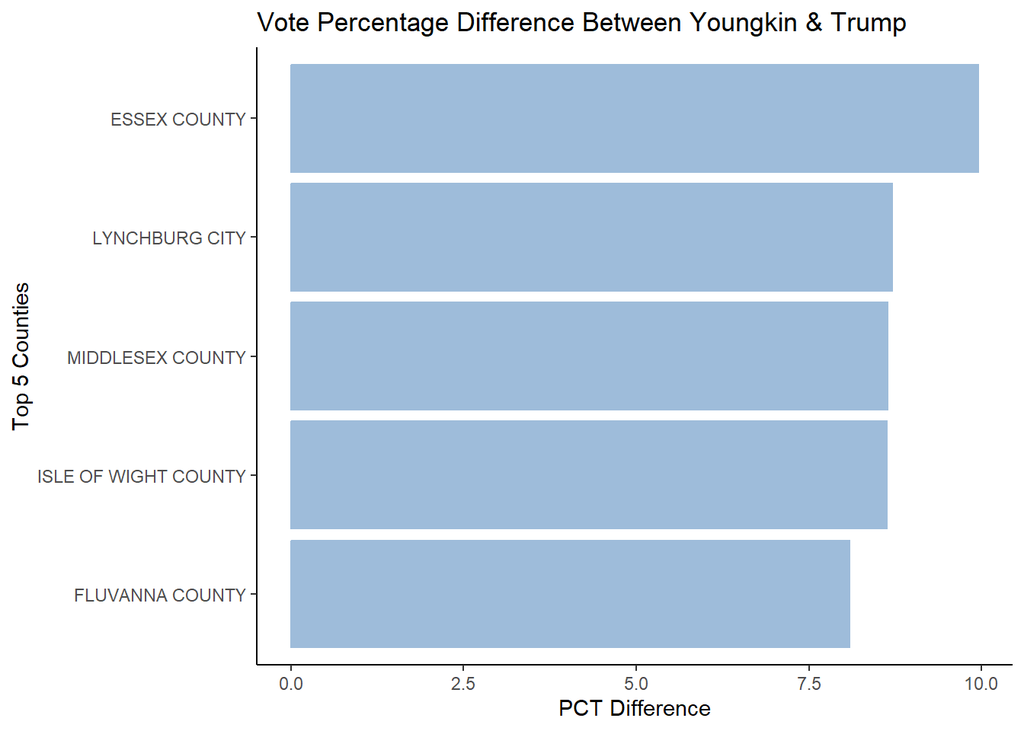

```r
youngkincounties <- joined_vacomparison %>%
  group_by(locality)%>%
  arrange(-`pct_diff_YT$votemargin`)%>%
  head(5)%>%
  summarise(pctdifference=`pct_diff_YT$votemargin`)

youngkincounties %>%
  ggplot(aes(x = reorder(locality, pctdifference), y = pctdifference)) +
  geom_col(color = "#9ebcda", fill = "#9ebcda") +
  coord_flip() +
  scale_y_continuous(name = "PCT Difference", labels = scales::comma) +
  scale_x_discrete(name = "Top 5 Counties") +
  labs(title = "Vote Percentage Difference Between Youngkin & Trump") +
  theme_classic()
```

Create a chart that shows the Top 5 counties based on where Youngkin got the highest percentage of the vote

[figure not shown]

```r
youngkinwins <- joined_vacomparison %>%
  group_by(youngkin, trump) %>%
  arrange(-joined_vacomparison$youngkin+joined_vacomparison$trump)%>%
  head(5)%>%
  summarise(pcthigh=joined_vacomparison$youngkin+joined_vacomparison$trump)
youngkinhigh <- youngkinwins %>%
  mutate(
    pct_youngkin = janitor::round_half_up(youngkin / pcthigh * 100, 2), trump_pct = janitor::round_half_up(trump/ pcthigh *100, 2)
  ) %>%
  head(5)

youngkinhigh %>%
  ggplot(aes(x = reorder(youngkin, pcthigh), y = pcthigh)) +
  geom_col(color = "#9ebcda", fill = "#9ebcda") +
  coord_flip() +
  scale_y_continuous(name = "Vote %", labels = scales::comma) +
  scale_x_discrete(name = "Counties") +
  labs(title = "Top Youngkin Counties") +
  theme_classic()
```

Create a table that shows the Top 5 counties based on where McCauliffe got the highest percentage of the vote

```r
joined_vacomparison <- readRDS(here("processed_data", "joined_vacomparison.rds"))

McCauliffvstrump <- (joined_vacomparison) %>%
  group_by(pct_mcauliffe, trump_pct)

head(McCauliffvstrump)
```

```
# A tibble: 6 x 9
# Groups:   pct_mcauliffe, trump_pct [6]
  locality       biden trump biden_pct trump_pct youngkin mcauliffe pct_youngkin
  <chr>          <dbl> <dbl>     <dbl>     <dbl>    <int>     <int>        <dbl>
1 ACCOMACK COUN~  7578  9172      44.7      54.1     7878      4948         61.1
2 ALBEMARLE COU~ 42466 20804      65.7      32.2    19141     31919         37.2
3 ALEXANDRIA CI~ 66240 14544      80.3      17.6    14013     43866         24.0
4 ALLEGHANY COU~  2243  5859      27.3      71.4     4530      1518         74.5
5 AMELIA COUNTY   2411  5390      30.6      68.3     4720      1617         74.2
6 AMHERST COUNTY  5672 11041      33.4      64.9     9731      3897         71
# ... with 1 more variable: pct_mcauliffe <dbl>
```

[figure not shown]

```r
pct_diff_MCT <- McCauliffvstrump %>%
  group_by(trump_pct, pct_mcauliffe) %>%
  summarise(votemargin=pct_mcauliffe-trump_pct)
joined_vacomparison<- cbind(joined_vacomparison, pct_diff_MCT$votemargin)


McCauliffecounties <- joined_vacomparison %>%
  group_by(locality)%>%
  arrange(-pct_diff_MCT$votemargin)%>%
  head(5)%>%
  summarise(pctdifference=pct_diff_MCT$votemargin)
McCauliffecounties %>%
  ggplot(aes(x = reorder(locality, pctdifference), y = pctdifference)) +
  geom_col(color = "#9ebcda", fill = "#9ebcda") +
  coord_flip() +
  scale_y_continuous(name = "PCT Difference", labels = scales::comma) +
  scale_x_discrete(name = "Top 5 Counties") +
  labs(title = "Vote Percentage Difference Between McCauliffe & Trump") +
  theme_classic()
```

Based on your own analysis, explain a finding of your choosing, include a narrative explaining it to the audience and then create either a chart or table displaying it.

```r
joined_vacomparison <- readRDS(here("processed_data", "joined_vacomparison.rds"))

governorrace <- (joined_vacomparison) %>%
  group_by(pct_mcauliffe, pct_youngkin, locality) %>%
  head(5) %>%
  summarise(votemargin = pct_youngkin-pct_mcauliffe)
head(governorrace)
```

```
# A tibble: 5 x 4
# Groups:   pct_mcauliffe, pct_youngkin [5]
  pct_mcauliffe pct_youngkin locality         votemargin
          <dbl>        <dbl> <chr>                 <dbl>
1          25.0         74.5 ALLEGHANY COUNTY       49.6
2          25.4         74.2 AMELIA COUNTY          48.8
3          38.4         61.1 ACCOMACK COUNTY        22.7
4          62.0         37.2 ALBEMARLE COUNTY      -24.8
5          75.2         24.0 ALEXANDRIA CITY       -51.2
```

```r
pct_diff_MY <- governorrace %>%
  group_by(pct_mcauliffe, pct_youngkin, locality) %>%
  summarise(votemargin=pct_youngkin-pct_mcauliffe)
```

Based on your own analysis, explain a second finding of your choosing, include a narrative explaining it to the audience and then create either a chart or table displaying it.

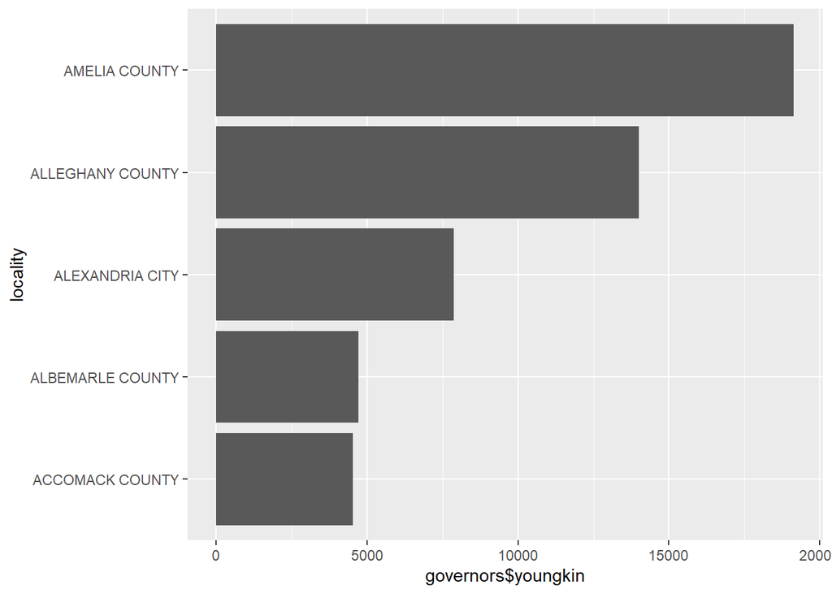

```r
joined_vacomparison <- readRDS(here("processed_data", "joined_vacomparison.rds"))

governorvotes <- (joined_vacomparison) %>%
  group_by(youngkin) %>%
  head(5)

governors<- governorvotes %>%
  group_by(youngkin, mcauliffe)%>%
  head(5)%>%
  summarise()
ggplot(governorvotes, aes(x = governors$youngkin, y = locality)) +
  geom_col()+
  scale_fill_manual(values = c("#468189", "#9DBEBB"))
```

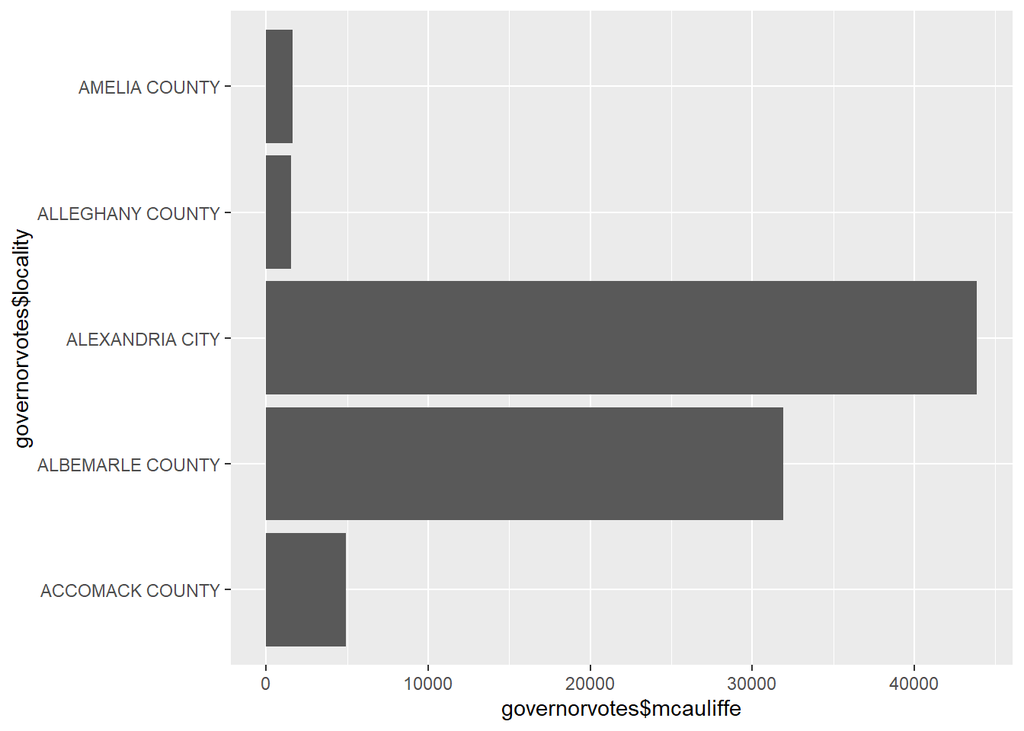

```r
ggplot(governorvotes, aes(x = governorvotes$locality, y = governorvotes$mcauliffe)) +
  geom_col()+
  coord_flip()+
  scale_fill_manual(values = c("#468189", "#9DBEBB"))
```

Based on your own analysis, explain a third finding of your choosing, include a narrative explaining it to the audience and then create either a chart or table displaying it.

```r
joined_vacomparison <- readRDS(here("processed_data", "joined_vacomparison.rds"))

presZ_race <- (joined_vacomparison) %>%
  group_by(biden_pct, trump_pct) %>%
  head(5)

govs_race <- (joined_vacomparison)

govs_race <- (joined_vacomparison) %>%
  group_by(govs_race$pct_youngkin, govs_race$pct_mcauliffe) %>%
  head(5)


pct_diff_elec <- merge(govs_race, presZ_race) %>%
  group_by(locality) %>%
  summarise(votecount=mean(biden_pct-trump_pct), mean(pct_youngkin-pct_mcauliffe))

head(pct_diff_elec)
```

```
# A tibble: 5 x 3
  locality         votecount `mean(pct_youngkin - pct_mcauliffe)`
  <chr>                <dbl>                                <dbl>
1 ACCOMACK COUNTY      -9.39                                 22.7
2 ALBEMARLE COUNTY     33.5                                 -24.8
3 ALEXANDRIA CITY      62.6                                 -51.2
4 ALLEGHANY COUNTY    -44.1                                  49.6
5 AMELIA COUNTY       -37.7                                  48.8
```

In This table is the mean difference or gap of votes between presidential and gubernatorial candidates. The difference in votes seems to be slightly higher in the gubenatorial race compared to the presidential race.

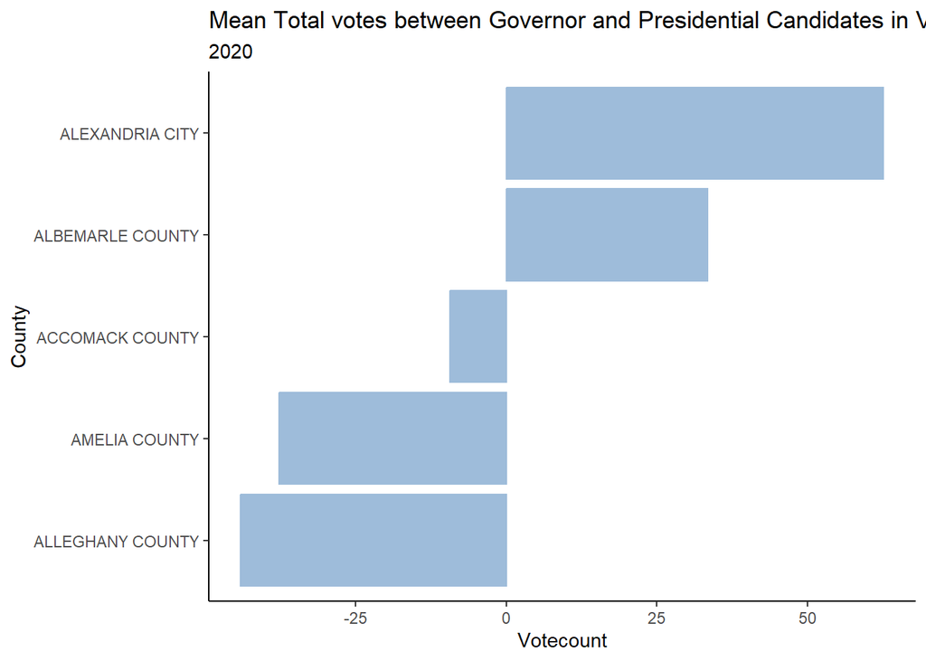

```r
pct_diff_elec %>%
  ggplot(aes(x= reorder(locality, votecount), y = votecount ))+
  geom_col(color = "#9ebcda", fill = "#9ebcda")+
  coord_flip()+
  scale_y_continuous(name = "Votecount", labels = scales::comma) +
  scale_x_discrete(name = "County") +
  labs(title = "Mean Total votes between Governor and Presidential Candidates in Virginia",
       subtitle = "2020") +
  theme_classic()
```